# Project.Part.1.AS

Jake Harvey

2025-03-02

# NYC Crimes 2024

# 1.

| ARREST_KEY | ARREST_DATE | PD_CD | PD_DESC | KY_CD | OFNS_DESC | LAW_CODE | LAW_CAT_CD | ARREST_BORO | ARREST_PRECINCT | JURISDICTION_CODE | AGE_GROUP | PERP_SEX | PERP_RACE | X_COORD_CD | Y_COORD_CD | Latitude | Longitude | New.Georeferenced.Column |
| --- | --- | --- | --- | --- | --- | --- | --- | --- | --- | --- | --- | --- | --- | --- | --- | --- | --- | --- |
| 281369711 | 1/30/2024 | 177 | SEXUAL ABUSE | 116 | SEX CRIMES | PL 1306501 | F | M | 25 | 0 | 25-44 | M | BLACK | 1000558 | 231080 | 40.80093 | -73.94110 | POINT (-73.9410982410066 40.8009303727402) |
| 284561406 | 3/30/2024 | 105 | STRANGULATION 1ST | 106 | FELONY ASSAULT | PL 1211200 | F | B | 44 | 0 | 25-44 | M | BLACK | 1004297 | 242846 | 40.83321 | -73.92755 | POINT (-73.927554 40.833209) |
| 284896016 | 4/6/2024 | 105 | STRANGULATION 1ST | 106 | FELONY ASSAULT | PL 1211200 | F | M | 19 | 0 | 25-44 | M | BLACK | 997304 | 222853 | 40.77835 | -73.95286 | POINT (-73.952863 40.778348) |
| 285569016 | 4/18/2024 | 105 | STRANGULATION 1ST | 106 | FELONY ASSAULT | PL 1211200 | F | K | 69 | 0 | 25-44 | M | BLACK | 1010576 | 175628 | 40.64870 | -73.90513 | POINT (-73.905128 40.648698) |
| 287308954 | 5/22/2024 | 464 | JOSTLING | 230 | JOSTLING | PL 1652501 | M | M | 18 | 0 | 18-24 | M | WHITE | 991530 | 217373 | 40.76331 | -73.97372 | POINT (-73.973717 40.763313) |
| 286793332 | 5/13/2024 | 155 | RAPE 2 | 104 | RAPE | PL 1303001 | F | Q | 112 | 0 | 18-24 | M | BLACK HISPANIC | 1025401 | 202586 | 40.72264 | -73.85154 | POINT (-73.8515418216779 40.7226409964758) |

# 2.

Link to previous assignment: https://jake7harvey.github.io/Applied-Statistics-2025/MOD-0.html

Random Number Generator

```r
numCores <- detectCores() - 1
cl <- makeCluster(numCores)
registerDoParallel(cl)

Generate_Random_Age <- function(Age_Range) {
  case_when(
    Age_Range == '<18' ~ sample(15:17, 1),
    Age_Range == '18-24' ~ sample(18:24, 1),
    Age_Range == '25-44' ~ sample(25:44, 1),
    Age_Range == '45-64' ~ sample(45:64, 1),
    Age_Range == '65+' ~ sample(65:75, 1)
  )
}

Random_Ages <- foreach(age_group = df$AGE_GROUP, .combine = c, .packages = 'dplyr') %dopar% {
  Generate_Random_Age(age_group)
}

df <- df |> mutate(Random_Ages = Random_Ages)

stopCluster(cl)
```

I am also going to divide the ages into their respective police borough just to have a more visually apealing graph and data set. It will also help with predictions down the line.

```r
manhattan <- subset(df, ARREST_BORO == "M")
bronx <- subset(df, ARREST_BORO == "B")
brooklyn <- subset(df, ARREST_BORO == "K")
queens <- subset(df, ARREST_BORO == "Q")
staten_island <- subset(df, ARREST_BORO == "S")
```

# 3.

## A.

I am going to do a random sample of the whole df just to make it more readable.

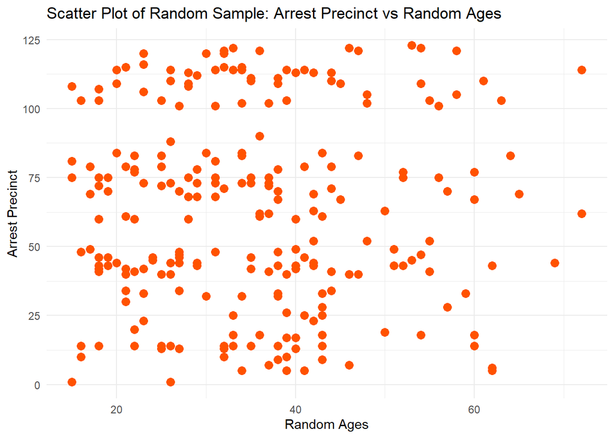

```r
correlation <- cor(random_sample$Random_Ages, random_sample$ARREST_PRECINCT)
cat("Correlation between Random Ages and Arrest Precinct: ", correlation, "\n")
```

```
## Correlation between Random Ages and Arrest Precinct:  0.008230169
```

```r
random.model <- lm(ARREST_PRECINCT ~ Random_Ages, data = random_sample)

summary(random.model)
```

```
##
## Call:
## lm(formula = ARREST_PRECINCT ~ Random_Ages, data = random_sample)
##
## Residuals:
##     Min      1Q  Median      3Q     Max
## -62.315 -23.315  -1.203  37.428  59.069
##
## Coefficients:
##             Estimate Std. Error t value Pr(>|t|)
## (Intercept)  62.7225     6.6010   9.502   <2e-16 ***
## Random_Ages   0.0228     0.1759   0.130    0.897
## ---
## Signif. codes:  0 '***' 0.001 '**' 0.01 '*' 0.05 '.' 0.1 ' ' 1
##
## Residual standard error: 35.2 on 248 degrees of freedom
## Multiple R-squared:  6.774e-05,  Adjusted R-squared:  -0.003964
## F-statistic: 0.0168 on 1 and 248 DF,  p-value: 0.897
```

The correlation here is nonexistant. I was thinking that there may be a certain precinct that gets more of a certain age group, but I was mistaken.

Here is the graph of the whole dataset.

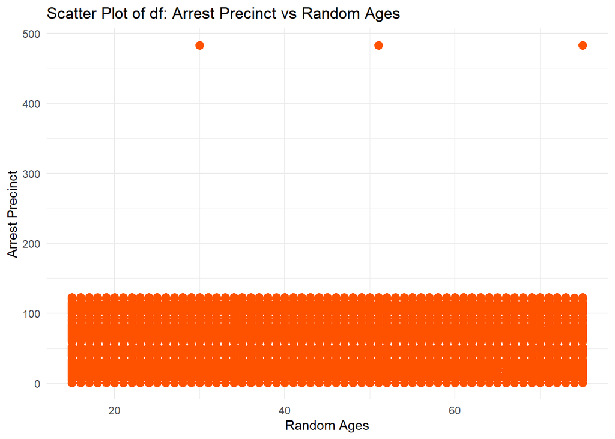

```r
correlation <- cor(df$Random_Ages, df$ARREST_PRECINCT)
cat("Correlation between Random Ages and Arrest Precinct: ", correlation, "\n")
```

```
## Correlation between Random Ages and Arrest Precinct:  -0.014067
```

```r
whole.model <- lm(ARREST_PRECINCT ~ Random_Ages, data = df)

summary(whole.model)
```

```
##
## Call:
## lm(formula = ARREST_PRECINCT ~ Random_Ages, data = df)
##
## Residuals:
##    Min     1Q Median     3Q    Max
## -63.21 -23.61  -0.76  37.79 421.06
##
## Coefficients:
##              Estimate Std. Error t value Pr(>|t|)
## (Intercept) 64.783955   0.203110  318.96  < 2e-16 ***
## Random_Ages -0.037979   0.005289   -7.18 6.97e-13 ***
## ---
## Signif. codes:  0 '***' 0.001 '**' 0.01 '*' 0.05 '.' 0.1 ' ' 1
##
## Residual standard error: 34.95 on 260501 degrees of freedom
## Multiple R-squared:  0.0001979,  Adjusted R-squared:  0.000194
## F-statistic: 51.56 on 1 and 260501 DF,  p-value: 6.969e-13
```

Well there are a few outliers, I wasn’t expecting that, but there is still no correlation.

## B.

```r
coeff <- coef(whole.model)
cat("Slope (b1): ", coeff[2], "\n")
```

```
## Slope (b1):  -0.03797851
```

```r
new_data <- data.frame(Random_Ages = 22)
predicted <- predict(whole.model, new_data, interval = "confidence")
cat("Predicted Arrest Precinct: ", predicted, "\n")
```

```
## Predicted Arrest Precinct:  63.94843 63.74958 64.14728
```

```r
actual <- 65
residual <- actual - predicted[1]
cat("Residual: ", residual, "\n")
```

```
## Residual:  1.051572
```

## C.

```
##
##  Pearson's product-moment correlation
##
## data:  df$Random_Ages and df$ARREST_PRECINCT
## t = -7.1804, df = 260501, p-value = 6.969e-13
## alternative hypothesis: true correlation is not equal to 0
## 95 percent confidence interval:
##  -0.01790613 -0.01022746
## sample estimates:
##       cor
## -0.014067
```

## D.

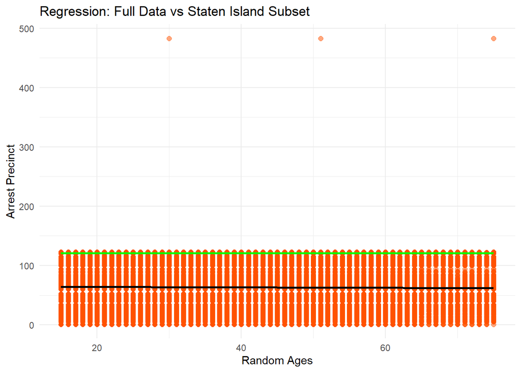

Staten Island tends to lie on one of the higher number precincts. Restricting the data might change the graph, but only so many precincts lie within each district, which in turn would skew certain regressions to one side or the other.

## E.

```
##
## Call:
## lm(formula = ARREST_PRECINCT ~ Random_Ages + PERP_SEX, data = df)
##
## Residuals:
##    Min     1Q Median     3Q    Max
## -64.26 -23.56  -0.74  37.67 421.27
##
## Coefficients:
##             Estimate Std. Error t value Pr(>|t|)
## (Intercept) 65.82261    0.24810 265.312  < 2e-16 ***
## Random_Ages -0.03725    0.00529  -7.041 1.91e-12 ***
## PERP_SEXM   -1.29908    0.17823  -7.289 3.13e-13 ***
## ---
## Signif. codes:  0 '***' 0.001 '**' 0.01 '*' 0.05 '.' 0.1 ' ' 1
##
## Residual standard error: 34.95 on 260500 degrees of freedom
## Multiple R-squared:  0.0004017,  Adjusted R-squared:  0.0003941
## F-statistic: 52.35 on 2 and 260500 DF,  p-value: < 2.2e-16
```

```
## Predicted Arrest Precinct:  63.62962
```

There is no true correlation with age, sex, and precincts in this data. With what is given, a low prediction level is assumed.

Just out of curiosity, I am going to try the same thing with my random sample data.

```
##
## Call:
## lm(formula = ARREST_PRECINCT ~ Random_Ages + PERP_SEX, data = random_sample)
##
## Residuals:
##     Min      1Q  Median      3Q     Max
## -64.225 -27.372  -0.109  28.531  61.315
##
## Coefficients:
##              Estimate Std. Error t value Pr(>|t|)
## (Intercept)  72.20717    7.96430   9.066   <2e-16 ***
## Random_Ages   0.02366    0.17469   0.135    0.892
## PERP_SEXM   -11.77613    5.61412  -2.098    0.037 *
## ---
## Signif. codes:  0 '***' 0.001 '**' 0.01 '*' 0.05 '.' 0.1 ' ' 1
##
## Residual standard error: 34.96 on 247 degrees of freedom
## Multiple R-squared:  0.01757,    Adjusted R-squared:  0.009613
## F-statistic: 2.208 on 2 and 247 DF,  p-value: 0.112
```

```
## Predicted Arrest Precinct:  60.99887
```

## F.

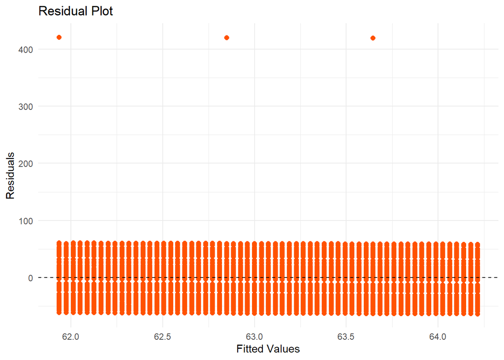

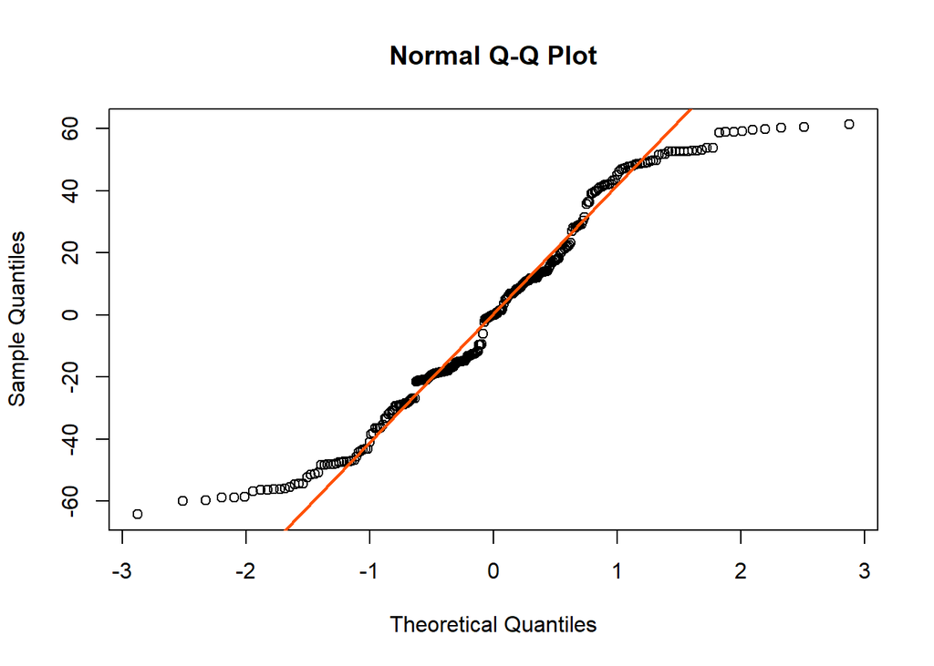

# 4.

My data set is all of the arrests made in 2024 in New York City. The information that is provided by the data set contains everything regarding the arrests up to who the person was. Crimes, categories of crime, dates, and arresting boroughs are just some parts of this data set. The age range of the suspect is a big part of this data set as well as the arresting boroughs. I found the data set on data.gov.

Link: https://catalog.data.gov/dataset/nypd-arrest-data-year-to-date

The conclusion that I can draw from this assignment is that correlations between age and where you are arrested have virtualy no relation. Throughout that point kept being proven. One thing that might have correlation could be the type of crime commited and age. This would tell us the most popular crime for certain ages to commit, and possibly predict it. Overall, I am satisfied with the work, even though some of it is ugly and looks like someone threw up. Not to mention I did have to look some things up to get them to work, but it is fine.